# Federated privacy-protected bioinformatic GWAS analysis using `DataSHIELD + Opal` infrastructure

Xavier Escriba-Montagut and Juan R. Gonzalez

Bioinformatics Research Group in Epidemiolgy (BRGE), Barcelona Insitute for Global Health (ISGlobal)  
Department of Mathematics, Autonomous University of Barcelona (UAB)

juanr.gonzalez@isglobal.org

2021-09-22

#### Package

dsOmicsClient 1.0.7.6, dsOmics (in the https://opal-demo.obiba.org demo Opal) 1.0.7-6 resourcer min. version 1.2.0 (server), dsBase min. version 6.1.1 (server)

# 1 Introduction

# 2 Purpose

[…]

The functions to be executed in the local side (i.e. data analyst machine) will extremely facilitate the bioinformatic analyses by running simple R sentences for each of the required genomic data analysis. These functions are implemented in the [dsOmicsClient](https://rpubs.com/jrgonzalezISGlobal/tutorial_DSomics) package that includes:

- Principal component analyses (population stratification)
- Allele frequency
- Hardy-Weinberg equillibrium test
- Single association analyses (meta-analysis and mega-analysis, e.g pooled data)
- GWAS (meta-analysis)
- Polygenic risk score (PRS)

The package also allows to perform:

- Epigenome-wide association analyses
- Meta-analyses
- Post-omic data analyses (e.g. pathway/enrichment)

# 3 Use cases

Three different use cases will be illustrate:

- Single cohort GWAS. Using data from all the individuals.
- Multi-cohort GWAS. Using the same individuals as the single cohort separated into three synthetic cohorts.
- Polygenic risk score. Using data from all the individuals.

It’s important noting that the data for the use cases is divided by chromosome (VCF files). It can be run by using a single VCF that contains all the variants, it is just not advisable from a performance point of view.

The data used along this section is a synthetic data set generated by the CINECA project made freely available under the Creative Commons Licence (CC-BY) (funding: EC H2020 grant 825775). It has been pruned and the individuals have been separated into three synthetic cohorts. For the “Single cohort” use case, all the individuals are used. Information on individuals and SNP count of each cohort can be found on the Table 1.

Table 1: Numer of SNPs and individuals by cohort

[output not shown]

## 3.1 Single cohort

The single cohort analysis is a way of performing a GWAS study guaranteeing GDPR data confidentiality. The structure followed is illustrated on the following figure.

[figure not shown]

Figure 1: Proposed infrastructure to perform single-cohort GWAS studies

The data analyst corresponds to the “RStudio” session, which through DataSHIELD Interface (DSI) connects with the Opal server located at the cohort network. This Opal server contains an array of resources that correspond to the different VCF files (sliced by chromosome) and a resource that corresponds to the phenotypes table of the studied individuals.

The same methodology and code can be used with unitary VCF resources that contain the variant information of all chromosomes.

### 3.1.1 Connection to the Opal server

We have to create an Opal connection object to the cohort server. We do that using the following functions.

```r
require('DSI')
require('DSOpal')
require('dsBaseClient')
require('dsOmicsClient')

builder <- DSI::newDSLoginBuilder()
builder$append(server = "cohort1", url = "https://opal-demo.obiba.org/",
               user =  "dsuser", password = "password",
               driver = "OpalDriver", profile = "omics")
logindata <- builder$build()
conns <- DSI::datashield.login(logins = logindata)
```

### 3.1.2 Assign the VCF resources

Now that we have created a connection object to the Opal, we have started a new R session on the server, our analysis will take place in this remote session, so we have to load the data into it. This is done via a two step process:

1. Load the resources to the R session. The resources can be imagined as a data structure that contains the information about were to find a data set and the access credentials to it; we as users are not able to look at this information (it is privately stored on the Opal server), but we can load it into our remote R session to make use of it. Following that, the second step comes naturally.
2. Resolve the resources. Once we have the information on how to access the data, we have to actually retrieve it on the remote R session to analyze it.

In this use case we will use 21 different resources from the `GWAS` project hosted on the [demo Opal server](https://opal-demo.obiba.org/). This resources correspond to VCF files with information on individual chromosomes. The names of the resources are `chrXXA` (where XX is the chromosome number). Following the Opal syntax, we will refer to them using the string `GWAS.chrXXA`.

To load the resources we will use the `DSI::datashield.assign.resource()` function. Note that along the use case we use the `lapply` function to simplify our code since we have to perform repetitive operations. `lapply` is a way of creating loops in R, for more information visit [the documentation](https://www.rdocumentation.org/packages/base/versions/3.6.2/topics/lapply).

```r
lapply(1:21, function(x){
  DSI::datashield.assign.resource(conns, paste0("chr", x), paste0("GWAS.chr", x))
  })
```

Now we have assigned all the resources named `GWAS.chrXXA` into our remote R session. We have assigned them to the variables called `chrXX`. To verify this step has been performed correctly, we could use the `ds.class` function to check for their class and that they exist on the remote session.

```r
ds.class("chr1")
```

```
$cohort1
[1] "GDSFileResourceClient" "FileResourceClient"    "ResourceClient"
[4] "R6"
```

To resolve the resources and retrieve the data in the remote session we will use the `DSI::datashield.assign.expr()` function. This function runs a line of code on the remote session, and in particular we want to run the function `as.resource.object()`, which is the DataSHIELD function in charge of resolving the resources.

The same methodology and code can be used with unitary VCF resources that contain the variant information of all chromosomes.

```r
lapply(1:21, function(x){
  DSI::datashield.assign.expr(conns = conns, symbol = paste0("gds", x, "_object"),
                            expr = as.symbol(paste0("as.resource.object(chr", x, ")")))
})
```

Now we have resolved the resources named `chrXX` into our remote R session. The objects retrieved have been assigned into variables named `gdsXX_object`. We can check the process was successful as we did before.

```r
ds.class("gds1_object")
```

```
$cohort1
[1] "GdsGenotypeReader"
attr(,"package")
[1] "GWASTools"
```

### 3.1.3 Assign the phenotypes

The objects we have loaded into our remote session are VCF files that contain genomic information of the individuals. To perform a GWAS this information has to be related to some phenotypes to extract relationships. Therefore, we need to load the phenotypes into the remote session. The phenotypes information is a table that contains the individuals as rows and phenotypes as columns. In this use case, we will use a resource (as with the VCF files) to load the phenotypes table into the remote session.

The procedure is practically the same as before with some minor tweaks. To begin, we have the phenotypes information in a single table (hence, a single resource). Then, instead of using the function `as.resource.object`, we will use `as.resource.data.frame`, this is because before we were loading a special object (VCF file) and now we are loading a plain table, so the internal treatment on the remote session has to be different.

```r
DSI::datashield.assign.resource(conns, "feno", "GWAS.feno")
DSI::datashield.assign.expr(conns = conns, symbol = "feno_object",
                            expr = quote(as.resource.data.frame(feno)))
```

We can follow the same analogy as before to know that we have assigned the phenotypes table to a variable called `feno_object` on the remote R session.

There is one extra step needed to perform on the phenotypes table, making sure the column names do not contain special characters. Special characters in R (for column names) are spaces, symbols, etc. To make sure our column names do not have any of them, there is a special function on the `dsOmics` package. We will overwrite the phenotypes table with syntax correct names.

Here we can see the original column names.

```r
head(ds.colnames("feno_object")[[1]])
```

```
[1] "Age at cancer diagnosis"
[2] "Age at recruitment"
[3] "Amount of alcohol drunk on a typical drinking day"
[4] "Basophill count"
[5] "Behaviour of cancer tumour"
[6] "Body mass index (BMI)"
```

And we apply the `make_valid_column_namesDS` function.

```r
DSI::datashield.assign.expr(conns, "feno_object", as.symbol("make_valid_column_namesDS(feno_object)"))
```

We can check the resulting names.

```r
head(ds.colnames("feno_object")[[1]])
```

```
[1] "Age.at.cancer.diagnosis"
[2] "Age.at.recruitment"
[3] "Amount.of.alcohol.drunk.on.a.typical.drinking.day"
[4] "Basophill.count"
[5] "Behaviour.of.cancer.tumour"
[6] "Body.mass.index..BMI."
```

Now we have valid names on our phenotypes table so we can proceed.

### 3.1.4 Merge VCF (genotype) and phenotype information

Arrived at this point, we have 21 VCF objects (each one corresponds to a chromosome) and a phenotypes table on our remote session. The next step is merging each of the VCF objects with the phenotypes table. Before doing that however, we have to gather some information from the phenotypes table. The information to gather is summarized on the Table 2.

Table 2: Information to gather from the phenotypes table.

| Information | Details |
| --- | --- |
| Which column has the samples identifier? | Column name that contains the IDs of the samples. Those are the IDs that will be matched to the ones present on the VCF objects. |
| Which is the sex column on the covariates file? | Column name that contains the sex information. |
| How are males and how are females encoded into this column? | There is not a standard way to encode the sex information, some people use 0/1; male/female; etc. Our approach uses a library that requires a specific encoding, for that reason we need to know the ori… |
| Which is the case-control column? | Column name that contains the case/control to be studied. |
| What is the encoding for case and for control on this column? | Similar as the sex column, the case/control will be translated to the particular standard of the software we have used to develop our functionalities . |

It’s important to note that all the other encodings present on the case-control column that are not the case or control, will be turned into missings. As an example, if we have “cancer”/“no cancer”/“no information”/“prefer not to answer” we can specifcy case=“cancer,” control=“no cancer” and all the individuals with “no information”/“prefer not to answer” will be interpreted as missings.

If we are not sure about the exact column names, we can use the function `ds.colnames` as we did before. Also, we can use the function `ds.table1D` to check the level names of the categorical variables.

```r
ds.table1D("feno_object$sex")$counts
```

```
       feno_object$sex
female            1271
male              1233
Total             2504
```

```r
ds.table1D("feno_object$Diabetes.diagnosed.by.doctor")$counts
```

```
                     feno_object$Diabetes.diagnosed.by.doctor
Do not know                                               612
No                                                        632
Prefer not to answer                                      590
Yes                                                       668
Total                                                    2502
```

From the different functions we used, we can extract our answers (Summarized on the Table 3)

Table 3: Summary of options from the example phenotypes table.

| Question | Answer |
| --- | --- |
| Which column has the samples identifier? | “subject_id” |
| Which is the sex column on the covariates file? | “sex” |
| How are males and how are females encoded into this column? | “male”/“female” |
| Which is the case-control column of interest of the covariates? | “Diabetes.diagnosed.by.doctor” |
| What is the encoding for case and for control on this column? | “Yes”/“No” |

With all this information we can now merge the phenotypes and VCF objects into a type of object named GenotypeData. We will use the `ds.GenotypeData` function.

```r
lapply(1:21, function(x){
  ds.GenotypeData(x=paste0('gds', x,'_object'), covars = 'feno_object', columnId = "subject_id",
                  sexId = "sex", male_encoding = "male", female_encoding = "female",
                  case_control_column = "Diabetes.diagnosed.by.doctor", case = "Yes", control = "No",
                  newobj.name = paste0('gds.Data', x), datasources = conns)
})
```

The objects we just created are named `gds.DataXX` on the remote session. Now we are ready to perform a GWAS analysis. To perform a GWAS we have to supply this “Genotype Data” objects and some sort of formula in which we will specify the type of association we are interested on studying. The R language has it’s own way of writing formulas, a simple example would be the following (relate the `condition` to the `smoke` variable adjusted by `sex`):

```r
condition ~ smoke + sex
```

For this use case we will use the following formula.

```r
Diabetes.diagnosed.by.doctor ~ sex + HDL.cholesterol
```

### 3.1.5 Performing the GWAS

We are finally ready to achieve our ultimate goal, performing a GWAS analysis. We have our data (genotype + phenotypes) organized into the correspondent objects (GenotypeData) and our association formula ready. The function `ds.GWAS` is in charge of doing the analysis, we have to supply it with the names of the GenotypeData objects of the remote R session and the formula. Since we have 21 different objects, the `paste0` function is used to simplify the call.

```r
results_single <- ds.GWAS(genoData = paste0("gds.Data", 1:21), model = Diabetes.diagnosed.by.doctor ~ sex + HDL.cholesterol)[[1]]

results_single
```

```
# A tibble: 865,240 x 10
   rs        chr        pos n.obs  freq   p.value    Est Est.SE reference_allele
 * <chr>     <chr>    <int> <dbl> <dbl>     <dbl>  <dbl>  <dbl> <chr>
 1 rs4648446 1       2.89e6  1292 0.512   7.42e-6 -0.323 0.0721 C
 2 rs4659014 1       1.20e8  1296 0.587   8.74e-6  0.321 0.0723 T
 3 rs127465~ 1       2.90e6  1294 0.548   9.69e-6 -0.321 0.0725 C
 4 rs313728  1       8.62e7  1293 0.277   1.08e-5 -0.375 0.0852 C
 5 rs113272~ 1       1.17e8  1292 0.859   1.08e-5 -0.459 0.104  T
 6 rs173625~ 1       2.82e7  1293 0.864   2.26e-5 -0.466 0.110  C
 7 rs292001  1       2.30e7  1293 0.343   2.64e-5  0.327 0.0779 G
 8 rs741198~ 1       1.47e8  1294 0.932   3.16e-5  0.608 0.146  A
 9 rs580006~ 1       5.30e7  1293 0.929   3.69e-5  0.590 0.143  C
10 rs729056~ 1       5.30e7  1294 0.929   4.18e-5  0.586 0.143  G
# ... with 865,230 more rows, and 1 more variable: alternate_allele <chr>
```

We can display the results of the GWAS using a Manhattan plot.

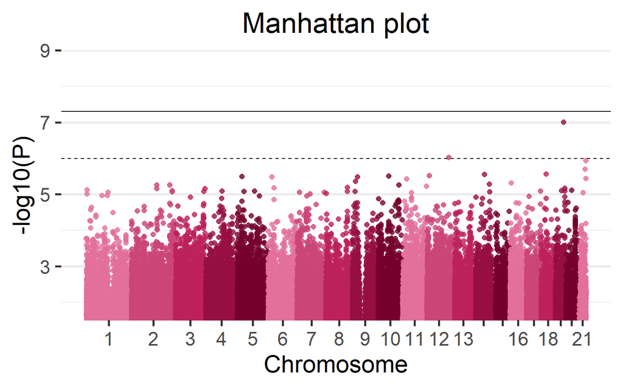

(#fig:singleCohortManhattan_plot)Manhattan plot of the single-cohort results.

```r
manhattan(results_single)
```

Moreover, we can visualize the region with the lowest p-value in detail using the function `LocusZoom`. There are multiple arguments to control the gene annotation, display a different region of the GWAS, display a different range of positions and more. Make sure to check `?LocusZoom` for all the details.

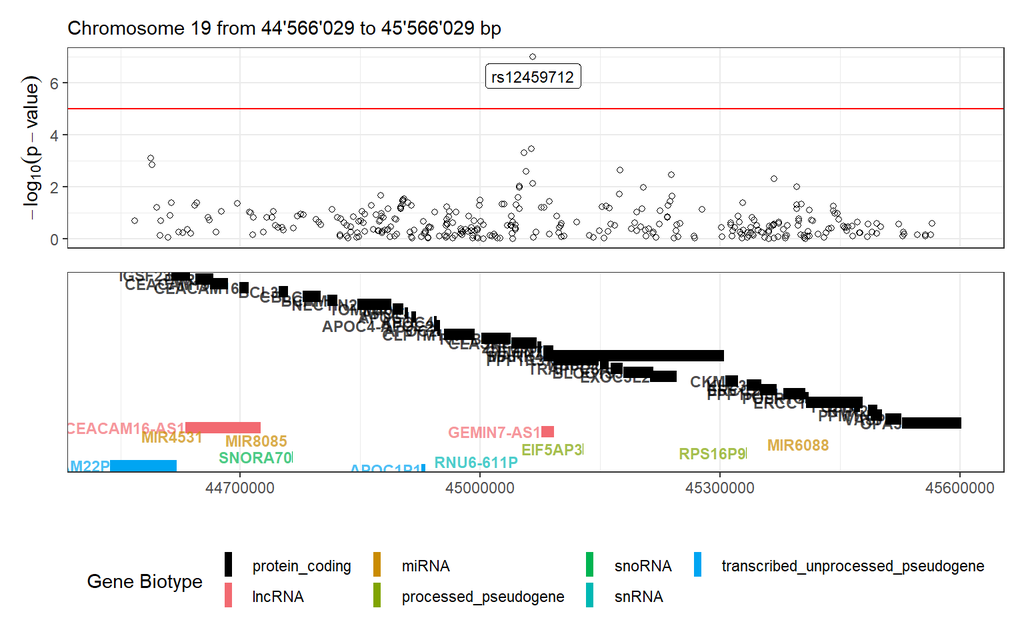

Figure 2: LocusZoom plot of the surrounding region of the top hit SNP

```r
LocusZoom(results_single)
```

```r
datashield.logout(conns)
```

## 3.2 Multi cohorts

Now all the individuals used for the single cohort use case will be divided into three different synthetic cohorts. The results from each cohort will then be meta-analyzed to be compared to the results obtained by studying all the individuals together. As with the single-cohort methodology illustrated on the prior section, this method guarantees GDPR data confidentiality. The structure for a three cohort study is illustrated on the following figure (note this can be extrapolated for cohorts with a bigger (or lower) partner count).

[figure not shown]

Figure 3: Proposed infrastructure to perform multi-cohort GWAS studies

The data analyst corresponds to the “RStudio” session, which through DataSHIELD Interface (DSI) connects with the Opal server located at the cohort network. This Opal server contains an array of resources that correspond to the different VCF files (sliced by chromosome) and a resource that corresponds to the phenotypes table of the studied individuals.

The same methodology and code can be used with unitary VCF resources that contain the variant information of all chromosomes.

### 3.2.1 Connection to the Opal server

We have to create an Opal connection object to the different cohorts server. We do that using the following functions.

```r
require('DSI')
require('DSOpal')
require('dsBaseClient')
require('dsOmicsClient')

builder <- DSI::newDSLoginBuilder()
builder$append(server = "cohort1", url = "https://opal-demo.obiba.org/",
               user =  "dsuser", password = "password",
               driver = "OpalDriver", profile = "omics")
builder$append(server = "cohort2", url = "https://opal-demo.obiba.org/",
               user =  "dsuser", password = "password",
               driver = "OpalDriver", profile = "omics")
builder$append(server = "cohort3", url = "https://opal-demo.obiba.org/",
               user =  "dsuser", password = "password",
               driver = "OpalDriver", profile = "omics")
logindata <- builder$build()
conns <- DSI::datashield.login(logins = logindata)
```

It is important to note that in this use case, we are only using one server that contains all the resources (https://opal-demo.obiba.org/), on this server there are all the resources that correspond to the different cohorts.

### 3.2.2 Assign the VCF resources

Now that we have created a connection object to the different Opals, we have started three R session, our analysis will take place on those remote sessions, so we have to load the data into them.

In this use case we will use 63 different resources from the `GWAS` project hosted on the [demo Opal server](https://opal-demo.obiba.org/). This resources correspond to VCF files with information on individual chromosomes (21 chromosomes per three cohorts). The names of the resources are `chrXXY` (where XX is the chromosome number and Y is the cohort A/B/C). Following the Opal syntax, we will refer to them using the string `GWAS.chrXXY`.

We have to refer specifically to each different server by using `conns[X]`, this allows us to communicate with the server of interest to indicate to it the resources that it has to load.

```r
# Cohort 1 resources
lapply(1:21, function(x){
  DSI::datashield.assign.resource(conns[1], paste0("chr", x), paste0("GWAS.chr", x,"A"))
  })

# Cohort 2 resources
lapply(1:21, function(x){
  DSI::datashield.assign.resource(conns[2], paste0("chr", x), paste0("GWAS.chr", x,"B"))
  })

# Cohort 3 resources
lapply(1:21, function(x){
  DSI::datashield.assign.resource(conns[3], paste0("chr", x), paste0("GWAS.chr", x,"C"))
  })
```

Now we have assigned all the resources named `GWAS.chrXXY` into our remote R session. We have assigned them to the variables called `chrXX`. To verify this step has been performed correctly, we could use the `ds.class` function to check for their class and that they exist on the remote sessions.

```r
ds.class("chr1")
```

```
$cohort1
[1] "GDSFileResourceClient" "FileResourceClient"    "ResourceClient"
[4] "R6"

$cohort2
[1] "GDSFileResourceClient" "FileResourceClient"    "ResourceClient"
[4] "R6"

$cohort3
[1] "GDSFileResourceClient" "FileResourceClient"    "ResourceClient"
[4] "R6"
```

We can see that the object `chr1` exists in all the three servers.

Finally the resources are resolved to retrieve the data in the remote sessions.

```r
lapply(1:21, function(x){
  DSI::datashield.assign.expr(conns = conns, symbol = paste0("gds", x, "_object"),
                            expr = as.symbol(paste0("as.resource.object(chr", x, ")")))
})
```

Now we have resolved the resources named `chrXX` into our remote R sessions. The objects retrieved have been assigned into variables named `gdsXX_object`. We can check the process was successful as we did before.

```r
ds.class("gds1_object")
```

```
$cohort1
[1] "GdsGenotypeReader"
attr(,"package")
[1] "GWASTools"

$cohort2
[1] "GdsGenotypeReader"
attr(,"package")
[1] "GWASTools"

$cohort3
[1] "GdsGenotypeReader"
attr(,"package")
[1] "GWASTools"
```

### 3.2.3 Assign the phenotypes

The objects we have loaded into our remote sessions are VCF files that contain genomic information of the individuals. To perform a GWAS this information has to be related to some phenotypes to extract relationships. Therefore, we need to load the phenotypes into the remote sessions. The phenotypes information is a table that contains the individuals as rows and phenotypes as columns. In this use case, we will use a resource (as with the VCF files) to load the phenotypes table into the remote sessions.

As with the VCF resources, here we load a different resource to each cohort, as it is expected that each cohort has only the phenotypes information regarding their individuals, therefore different tables. Note that we are assigning the resource to the same variable at each server (`feno`), so we only need one function call to resolve all the resources together.

```r
# Cohort 1 phenotypes table
DSI::datashield.assign.resource(conns[1], "feno", "GWAS.feno_samples1")

# Cohort 2 phenotypes table
DSI::datashield.assign.resource(conns[2], "feno", "GWAS.feno_samples2")

# Cohort 3 phenotypes table
DSI::datashield.assign.resource(conns[3], "feno", "GWAS.feno_samples3")

# Resolve phenotypes table
DSI::datashield.assign.expr(conns = conns, symbol = "feno_object",
                            expr = quote(as.resource.data.frame(feno)))
```

We can follow the same analogy as before to know that we have assigned the phenotypes table to a variable called `feno_object` on the remote R session.

There is one extra step needed to perform on the phenotypes table, making sure the column names do not contain special characters. Special characters in R (for column names) are spaces, symbols, etc. To make sure our column names do not have any of them, there is a special function on the `dsOmics` package. We will overwrite the phenotypes table with syntax correct names.

Here we can see the original column names.

```r
head(ds.colnames("feno_object")[[1]])
```

```
[1] "Age at cancer diagnosis"
[2] "Age at recruitment"
[3] "Amount of alcohol drunk on a typical drinking day"
[4] "Basophill count"
[5] "Behaviour of cancer tumour"
[6] "Body mass index (BMI)"
```

And we apply the `make_valid_column_namesDS` function.

```r
DSI::datashield.assign.expr(conns, "feno_object", as.symbol("make_valid_column_namesDS(feno_object)"))
```

We can check the resulting names.

```r
head(ds.colnames("feno_object")[[1]])
```

```
[1] "Age.at.cancer.diagnosis"
[2] "Age.at.recruitment"
[3] "Amount.of.alcohol.drunk.on.a.typical.drinking.day"
[4] "Basophill.count"
[5] "Behaviour.of.cancer.tumour"
[6] "Body.mass.index..BMI."
```

Now we have valid names on our phenotypes table so we can proceed.

### 3.2.4 Merge VCF (genotype) and phenotype information

Arrived at this point, we have 21 VCF objects at each cohort R session (each one corresponds to a chromosome) and a phenotypes table. The next step is merging each of the VCF objects with the phenotypes table. The same procedure as the single cohort can be applied to extract the arguments required.

With all this information we can now merge the phenotypes and VCF objects into a type of object named GenotypeData. We will use the `ds.GenotypeData` function.

```r
lapply(1:21, function(x){
  ds.GenotypeData(x=paste0('gds', x,'_object'), covars = 'feno_object', columnId = "subject_id", sexId = "sex",
                male_encoding = "male", female_encoding = "female",
                case_control_column = "Diabetes.diagnosed.by.doctor", case = "Yes", control = "No",
                newobj.name = paste0('gds.Data', x), datasources = conns)
})
```

The objects we just created are named `gds.DataXX` on the remote session. Now we are ready to perform a GWAS analysis. We will use the same formula as the single cohort to be able to compare the results later:

```r
Diabetes.diagnosed.by.doctor ~ sex + HDL.cholesterol
```

### 3.2.5 Performing the GWAS

We now proceed to perform the GWAS analysis.

```r
results <- ds.GWAS(genoData = paste0("gds.Data", 1:21), model = Diabetes.diagnosed.by.doctor ~ sex + HDL.cholesterol)
```

And we can see the results for each cohort.

#### Cohort 1

```
# A tibble: 865,162 x 10
   rs        chr        pos n.obs  freq   p.value    Est Est.SE reference_allele
 * <chr>     <chr>    <int> <dbl> <dbl>     <dbl>  <dbl>  <dbl> <chr>
 1 rs579533~ 1       3.90e7   430 0.737   3.28e-7  0.730  0.143 T
 2 rs113272~ 1       1.17e8   428 0.876   6.44e-7 -0.936  0.188 T
 3 rs4970551 1       3.90e7   350 0.749   6.02e-6  0.738  0.163 A
 4 rs9726184 1       2.81e7   430 0.801   6.50e-6  0.702  0.156 C
 5 rs2906466 1       4.43e7   428 0.551   8.79e-6 -0.563  0.127 A
 6 rs121172~ 1       1.87e8   428 0.407   8.87e-6 -0.600  0.135 T
 7 rs1626710 1       2.06e8   428 0.215   1.06e-5 -0.693  0.157 C
 8 rs109026~ 1       2.81e7   430 0.8     1.10e-5  0.679  0.155 G
 9 rs1938519 1       1.87e8   429 0.597   1.24e-5  0.587  0.134 A
10 rs1572823 1       1.99e7   428 0.189   1.24e-5 -0.740  0.169 T
# ... with 865,152 more rows, and 1 more variable: alternate_allele <chr>
```

#### Cohort 2

```
# A tibble: 865,190 x 10
   rs        chr        pos n.obs  freq   p.value    Est Est.SE reference_allele
 * <chr>     <chr>    <int> <dbl> <dbl>     <dbl>  <dbl>  <dbl> <chr>
 1 rs9426275 1       2.98e7   549 0.756   5.07e-6 -0.666  0.146 C
 2 rs124057~ 1       8.57e7   549 0.934   9.05e-5  0.917  0.234 A
 3 rs2762766 1       1.45e8   550 0.52    1.11e-4  1.18   0.305 T
 4 rs111615~ 1       8.58e7   549 0.779   1.80e-4  0.522  0.139 T
 5 rs4657641 1       1.67e8   552 0.343   2.54e-4 -0.416  0.114 G
 6 rs2295623 1       1.60e8   549 0.906   2.96e-4  0.715  0.197 C
 7 rs1891510 1       1.16e8   550 0.725   2.97e-4  0.499  0.138 T
 8 rs776826~ 1       2.21e8   551 0.928   3.06e-4 -0.802  0.222 C
 9 rs120926~ 1       3.13e7   551 0.819   3.68e-4 -0.546  0.153 C
10 rs6670319 1       1.16e8   552 0.724   3.99e-4  0.488  0.138 T
# ... with 865,180 more rows, and 1 more variable: alternate_allele <chr>
```

#### Cohort 3

```
# A tibble: 849,560 x 10
   rs        chr         pos n.obs  freq  p.value    Est Est.SE reference_allele
 * <chr>     <chr>     <int> <dbl> <dbl>    <dbl>  <dbl>  <dbl> <chr>
 1 rs4915771 1      62151742   285 0.593  2.77e-5 -0.700  0.167 G
 2 rs7544580 1      62178523   285 0.593  2.77e-5 -0.700  0.167 T
 3 rs1385117 1     102112168   286 0.893  3.81e-5  1.09   0.264 A
 4 rs121437~ 1     172319486   285 0.909  4.07e-5  1.16   0.283 T
 5 rs7521871 1     102110628   285 0.893  4.19e-5  1.08   0.264 G
 6 rs133739~ 1     102113861   285 0.893  4.19e-5  1.08   0.264 A
 7 rs600511~ 1     245057001   286 0.893  6.36e-5  1.08   0.271 T
 8 rs1938514 1     187349937   285 0.760  8.05e-5 -0.746  0.189 C
 9 rs121309~ 1     172358588   285 0.919  8.18e-5  1.16   0.295 G
10 rs761675~ 1     172361011   285 0.919  8.18e-5  1.16   0.295 G
# ... with 849,550 more rows, and 1 more variable: alternate_allele <chr>
```

### 3.2.6 GWAS Plots

We can display the results of the GWAS using a Manhattan plot for each cohort.

#### Cohort 1

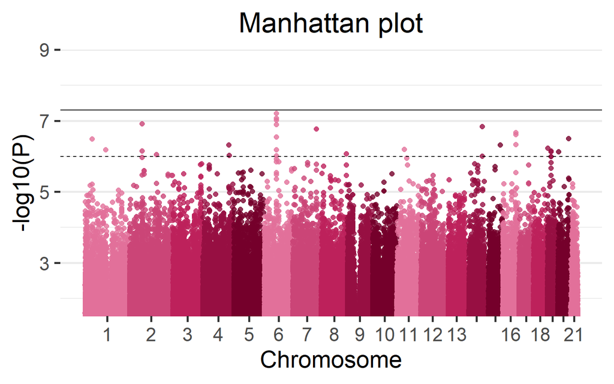

Figure 4: Manhattan plot of the Cohort 1

```r
manhattan(results[[1]])
```

#### Cohort 2

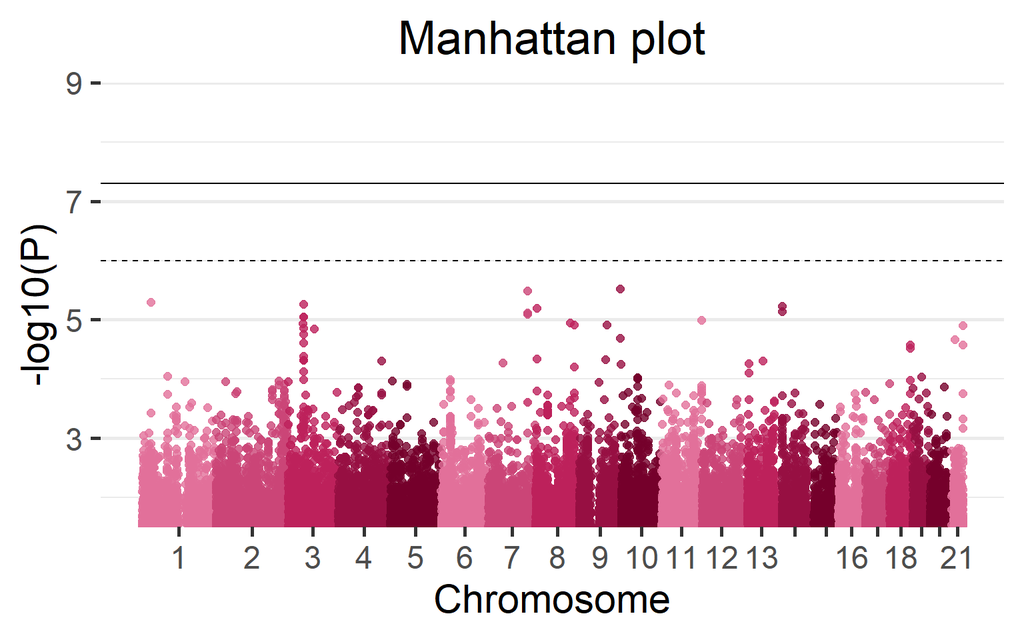

Figure 5: Manhattan plot of the Cohort 2

```r
manhattan(results[[2]])
```

#### Cohort 3

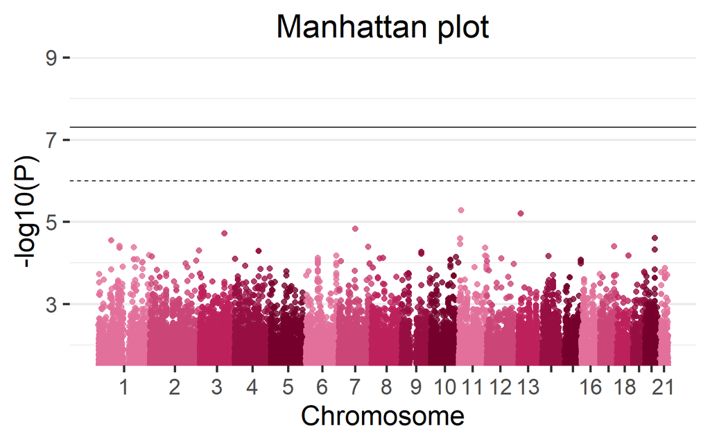

Figure 6: Manhattan plot of the Cohort 3

```r
manhattan(results[[3]])
```

### 3.2.7 Meta-analysis

Up to this point, we have obtained association results for each cohort on the study. The next step is to combine this information using meta-analysis methods to derive a pooled estimate closest to the common truth. Each researcher might have an already built pipeline to do so, or a preferred method; nevertheless, we included a couple methods inside `dsOmicsClient`. They are the following:

- Meta-analysis of p-values: Using the sum of logs method (Fisher’s method).
- Meta-analysis of beta values: Using a fixed-effects model. Methodology extracted and adapted from Pirinen (2020).

#### 3.2.7.1 Assessment of the meta-analysis methods

Previously, we have calculated the same GWAS analysis both using all the individuals and a simulated three-cohort scenario. This gives us the ability to assess how good or bad are the different meta-analysis methods on discovering the closest common truth; to do so, we will compare both meta-analysis to the common truth, the evaluation method will be counting the number of top hits that match the common truth, more specifically we will search for matches on the top twenty hits.

We apply both methods to the multi-cohort use case results:

```r
meta_pvalues <- metaPvalues(results)
meta_bvalues <- metaBetaValues(results)
```

We can now compare the 20 top hits from the common truth (previously stored on the variable `results_single`) to the 20 top hits yielded by both meta-analysis methodologies.

```r
# Extract 20 top hits for all three cases
  # All individuals
top_20_complete <- results_single %>% arrange(p.value) %>% head(20)
  # Pvalue meta-analysis
top_20_pval <- meta_pvalues %>% arrange(p.meta) %>% head(20)
  # Beta meta-analysis
top_20_beta <- meta_bvalues %>% arrange(pval) %>% head(20)

# Number of hits shared by all individuals case and beta meta-analysis
sum(top_20_complete$rs %in% top_20_beta$rs)
```

```
[1] 13
```

```r
# Number of hits shared by all individuals case and pvalue meta-analysis
sum(top_20_complete$rs %in% top_20_pval$rs)
```

```
[1] 1
```

The meta-analysis using beta values recovers a higher amount of top SNPs, therefore it can be considerated a more powerful method for GWAS meta-analyses.

#### 3.2.7.2 Visualizing the results of the meta-analysis

We can use the manhattan plot and locus zoom to visualize the results of the meta-analysis as we visualized the single cohorts before. To help assess the meta-analysis behaviour, we will plot together the common truth results (left plot) and the meta-analysis results (right plot).

##### 3.2.7.2.1 Manhatan plot

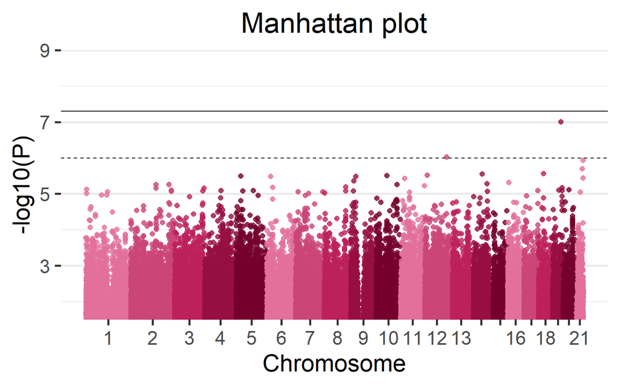

```r
manhattan(results_single)
```

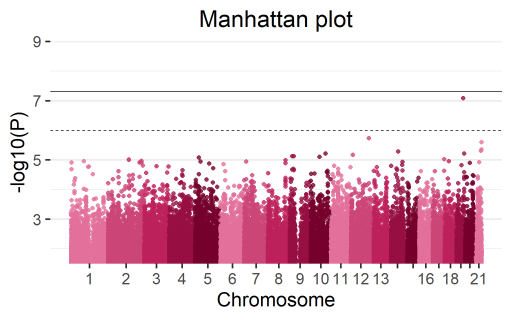

Figure 8: Manhattan plot of the meta-analysis results

```r
manhattan(meta_bvalues)
```

##### 3.2.7.2.2 LocusZoom

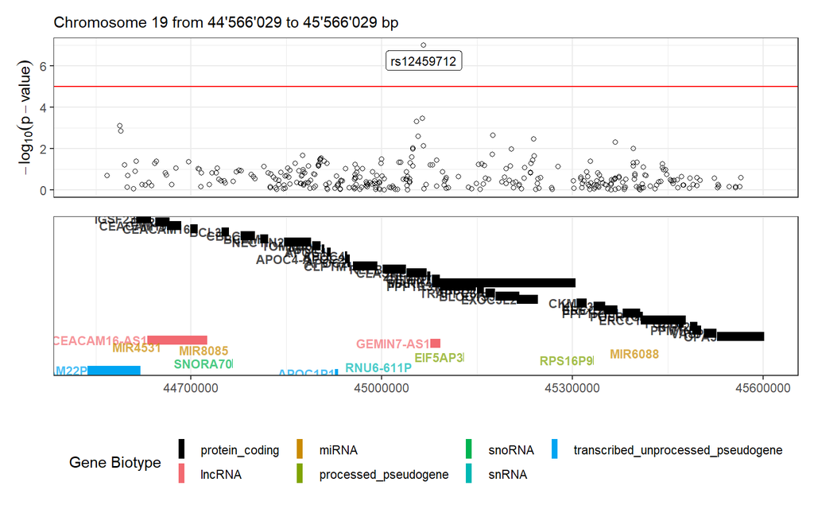

```r
LocusZoom(results_single)
```

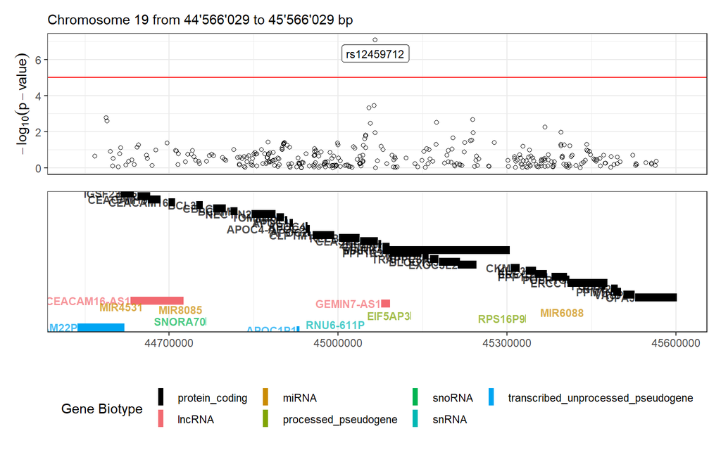

Figure 10: LocusZoom plot of the meta-analysis results

```r
LocusZoom(meta_bvalues, pvalue = "p.F")
```

#### 3.2.7.3 Meta-analysis versus pooled linear models

The `dsOmicsClient` package also bundles a function to fit pooled generalized linear models (GLM) on single (or multiple) SNPs. On this section we will compare the results of the meta-analysis to the pooled GLM models to see which method is closer to the common truth. The meta-analysis method will be the beta values (fixed-effects model).

The study methodology will be similar to the one we just performed. The top 20 hits yielded by the meta-analysis will be selected, those SNPs will be studied using the pooled GLM function. Both results will be compared to the common truth.

We aim to replicate a real scenario with this study, typically there is no access to the common truth (if so there is no point on performing meta-analysis on synthetic multi-cohorts), therefore we simulate the discovery of SNPs of interest via meta-analysis, then we want to assess if studying individually those SNPs using pooled GLM will put us closer to the common truth than what we already achieved.

We have already calculated the top 20 SNPs discovered by the beta meta-analysis.

```r
top_20_beta
```

```
# A tibble: 20 x 10
   rs        chr        pos    b.F   se.F        p.F    OR   low    up      pval
   <chr>     <chr>    <int>  <dbl>  <dbl>      <dbl> <dbl> <dbl> <dbl>     <dbl>
 1 rs124597~ 19      4.51e7 -0.530 0.0988    8.23e-8 0.589 0.485 0.714   8.23e-8
 2 rs956025  12      1.19e8 -0.406 0.0850    1.82e-6 0.667 0.564 0.787   1.82e-6
 3 rs8130070 21      4.57e7  0.398 0.0846    2.51e-6 1.49  1.26  1.76    2.51e-6
 4 rs8130914 21      4.68e7 -0.879 0.192     4.41e-6 0.415 0.285 0.604   4.41e-6
 5 rs9980256 21      4.24e7 -0.389 0.0852    4.92e-6 0.677 0.573 0.801   4.92e-6
 6 rs177569~ 14      6.92e7 -0.613 0.134     5.19e-6 0.542 0.416 0.705   5.19e-6
 7 rs112352~ 10      9.88e7  0.766 0.169     6.05e-6 2.15  1.54  3.00    6.05e-6
 8 rs721891  19      5.23e7 -0.491 0.109     6.11e-6 0.612 0.494 0.757   6.11e-6
 9 rs124233~ 12      1.24e7  0.710 0.158     6.77e-6 2.03  1.49  2.77    6.77e-6
10 rs9722322 9       2.79e7  0.345 0.0771    7.49e-6 1.41  1.21  1.64    7.49e-6
11 rs122370~ 9       1.72e7  0.499 0.111     7.50e-6 1.65  1.32  2.05    7.50e-6
12 rs169114~ 10      5.97e7  0.681 0.152     7.74e-6 1.97  1.47  2.66    7.74e-6
13 rs7714862 5       2.39e7  0.375 0.0842    8.30e-6 1.46  1.23  1.72    8.30e-6
14 rs8066656 17      7.65e7 -0.551 0.124     9.28e-6 0.576 0.452 0.735   9.28e-6
15 rs101939~ 2       1.39e8 -0.439 0.0992    9.60e-6 0.645 0.531 0.783   9.60e-6
16 rs101853~ 2       1.39e8 -0.409 0.0927    9.99e-6 0.664 0.554 0.796   9.99e-6
17 rs109558~ 8       1.19e8 -0.333 0.0754    1.01e-5 0.717 0.618 0.831   1.01e-5
18 rs581815  2       2.25e8 -0.343 0.0778    1.06e-5 0.710 0.609 0.827   1.06e-5
19 rs985355  18      2.70e7 -0.359 0.0816    1.10e-5 0.699 0.595 0.820   1.10e-5
20 rs313728  1       8.62e7 -0.389 0.0886    1.11e-5 0.677 0.569 0.806   1.11e-5
```

Next, we have to fit pooled GLM using the `ds.glmSNP` function, obviously we have to fit the same model that we did on the GWAS (`Diabetes.diagnosed.by.doctor ~ sex + HDL.cholesterol`), otherwise the results will not be consistent. Remember that we have the genotype data separated by chromosome, following that we will construct the GLM calls as follows:

```r
s <- lapply(1:nrow(top_20_beta), function(x){
  tryCatch({
    ds.glmSNP(snps.fit = top_20_beta[x, 1], model = Diabetes.diagnosed.by.doctor ~ sex + HDL.cholesterol, genoData = paste0("gds.Data", top_20_beta[x, 2]))
  }, error = function(w){NULL})
})
# Simple data cleaning and column name changes
ss <- data.frame(do.call(rbind, s))
ss <- ss %>% rownames_to_column("rs")
pooled <- ss %>% rename(Est.pooled = Estimate, SE.pooled = Std..Error, pval.pooled = p.value) %>% select(-c(n, p.adj))
```

We now extract the results of interest from the meta-analysis and the common truth.

```r
# Get data from all individuals study
original <- results_single %>% rename(pval.original = p.value, Est.original = Est, SE.original = Est.SE) %>%
  select(c(rs, Est.original, SE.original, pval.original))
# Arrange dadta from beta meta-analysis
beta <- top_20_beta %>% rename(pval.beta = pval, Est.beta = b.F, SE.beta = se.F) %>%
  select(c(rs, Est.beta, SE.beta, pval.beta))
# Merge all data on a single table
total <- Reduce(function(x,y){inner_join(x,y, by = "rs")}, list(original, pooled, beta))
```

With all the information gathered we can visualize the results the Table 4.

Table 4: Beta values, standard errors and p-values yielded by the three methods: GWAS of all individuals, meta-analysis of synthetic cohorts, pooled analysis of synthetic cohorts.

| SNP id | Beta Original | Beta Pooled | Beta Meta | SE Original | SE Pooled | SE Meta | P-Value Original | P-Value Pooled | P-Value Meta |
| --- | --- | --- | --- | --- | --- | --- | --- | --- | --- |
| rs313728 | −0.375 | −0.385 | −0.389 | 0.085 | 0.088 | 0.089 | 1.1 × 10<sup>−5</sup> | 1.2 × 10<sup>−5</sup> | 1.1 × 10<sup>−5</sup> |
| rs10193985 | −0.444 | −0.446 | −0.439 | 0.098 | 0.101 | 0.099 | 5.5 × 10<sup>−6</sup> | 1.1 × 10<sup>−5</sup> | 9.6 × 10<sup>−6</sup> |
| rs10185343 | −0.410 | −0.415 | −0.409 | 0.091 | 0.094 | 0.093 | 6.8 × 10<sup>−6</sup> | 1.1 × 10<sup>−5</sup> | 1.0 × 10<sup>−5</sup> |
| rs581815 | −0.341 | −0.344 | −0.343 | 0.077 | 0.079 | 0.078 | 8.4 × 10<sup>−6</sup> | 1.2 × 10<sup>−5</sup> | 1.1 × 10<sup>−5</sup> |
| rs7714862 | 0.376 | 0.371 | 0.375 | 0.081 | 0.084 | 0.084 | 3.2 × 10<sup>−6</sup> | 1.0 × 10<sup>−5</sup> | 8.3 × 10<sup>−6</sup> |
| rs10955881 | −0.331 | −0.331 | −0.333 | 0.073 | 0.075 | 0.075 | 6.5 × 10<sup>−6</sup> | 1.2 × 10<sup>−5</sup> | 1.0 × 10<sup>−5</sup> |
| rs9722322 | 0.353 | 0.345 | 0.345 | 0.076 | 0.078 | 0.077 | 3.3 × 10<sup>−6</sup> | 9.7 × 10<sup>−6</sup> | 7.5 × 10<sup>−6</sup> |
| rs12237062 | 0.497 | 0.499 | 0.499 | 0.108 | 0.113 | 0.111 | 4.3 × 10<sup>−6</sup> | 1.1 × 10<sup>−5</sup> | 7.5 × 10<sup>−6</sup> |
| rs112352624 | 0.685 | 0.814 | 0.766 | 0.160 | 0.186 | 0.169 | 1.9 × 10<sup>−5</sup> | 1.2 × 10<sup>−5</sup> | 6.0 × 10<sup>−6</sup> |
| rs956025 | −0.406 | −0.405 | −0.406 | 0.083 | 0.086 | 0.085 | 9.4 × 10<sup>−7</sup> | 2.3 × 10<sup>−6</sup> | 1.8 × 10<sup>−6</sup> |
| rs12423318 | 0.720 | 0.729 | 0.710 | 0.154 | 0.166 | 0.158 | 3.0 × 10<sup>−6</sup> | 1.1 × 10<sup>−5</sup> | 6.8 × 10<sup>−6</sup> |
| rs17756914 | −0.621 | −0.639 | −0.613 | 0.133 | 0.141 | 0.134 | 2.8 × 10<sup>−6</sup> | 5.8 × 10<sup>−6</sup> | 5.2 × 10<sup>−6</sup> |
| rs8066656 | −0.550 | −0.565 | −0.551 | 0.123 | 0.131 | 0.124 | 8.1 × 10<sup>−6</sup> | 1.7 × 10<sup>−5</sup> | 9.3 × 10<sup>−6</sup> |
| rs985355 | −0.376 | −0.366 | −0.359 | 0.080 | 0.083 | 0.082 | 2.7 × 10<sup>−6</sup> | 9.7 × 10<sup>−6</sup> | 1.1 × 10<sup>−5</sup> |
| rs12459712 | −0.510 | −0.528 | −0.530 | 0.096 | 0.101 | 0.099 | 9.9 × 10<sup>−8</sup> | 1.6 × 10<sup>−7</sup> | 8.2 × 10<sup>−8</sup> |
| rs721891 | −0.482 | −0.506 | −0.491 | 0.108 | 0.113 | 0.109 | 8.0 × 10<sup>−6</sup> | 7.7 × 10<sup>−6</sup> | 6.1 × 10<sup>−6</sup> |
| rs8130070 | 0.401 | 0.399 | 0.398 | 0.082 | 0.085 | 0.085 | 1.1 × 10<sup>−6</sup> | 2.8 × 10<sup>−6</sup> | 2.5 × 10<sup>−6</sup> |
| rs9980256 | −0.392 | −0.388 | −0.389 | 0.082 | 0.086 | 0.085 | 2.0 × 10<sup>−6</sup> | 5.9 × 10<sup>−6</sup> | 4.9 × 10<sup>−6</sup> |
| rs8130914 | −0.883 | −1.028 | −0.879 | 0.191 | 0.227 | 0.192 | 3.6 × 10<sup>−6</sup> | 5.7 × 10<sup>−6</sup> | 4.4 × 10<sup>−6</sup> |

Finally, to conclude this study we can compute the bias and mean squared error (code not shown). The resutls are shown on the Table 5.

Table 5: Mean squared error and bias for the betas from the meta-analysis and pooled analysis compared to the common truth (all individuals).

|  | MSE | Bias |
| --- | --- | --- |
| Beta |  |  |
| Pooled | 2.1 × 10<sup>−3</sup> | 5.2 × 10<sup>−3</sup> |
| Meta | 4.2 × 10<sup>−4</sup> | −2.7 × 10<sup>−3</sup> |

1. Perform GWAS with `dsOmicsClient::dsGWAS`
2. Perform meta-analysis on the results with `dsOmicsClient::metaBetaValues`
3. Extract top hits from the meta-analysis.
4. Perform pooled GLM on top hits with `dsOmicsClient::ds.glmSNP`

```r
datashield.logout(conns)
```

## 3.3 Polygenic risk scores

### 3.3.1 Definition

By checking for specific variants and quantifying them, a researcher can extract the polygenic risk score (PRS) of an individual, which translates to an associated risk of the individual versus a concrete phenotype. A definition of the term reads

> “A weighted sum of the number of risk alleles carried by an individual, where the risk alleles and their weights are defined by the loci and their measured effects as detected by genome wide association studies.” (Extracted from Torkamani, Wineinger, and Topol (2018))

The use of PRS markers is very popular nowadays and it has been proved to be a good tool to asses associated risks Escott-Price et al. (2017), Forgetta et al. (2020), Kramer et al. (2020).

When calculating the PRS using DataSHIELD, the actual scores are not returned, as it would not be GDPR compliant to be able to determine the risk of an individual versus a certain disease. The actual results are stored on the servers and optionally can be merged to the phenotypes table. This allows further study of the PRS using summaries or fitting pooled GLM models to assess relationships between phenotypes and PRS scores.

### 3.3.2 Study configuration

The PRS use case will be set up as a multi-cohort, using the same dataset as the multi-cohort GWAS (same VCF resources). A single cohort PRS could be performed analogously using the single cohort example of the GWAS.

### 3.3.3 Source of polygenic scores

There are two ways of stating the SNPs of interest and their weights in order to calculate the PRS.

- Providing a `prs_table` (SNPs of interest) table. The `prs_table` table has to have a defined structure and column names in order to be understood by this function. This table can be formulated using two schemas:
  - Scheme 1: Provide SNP positions. Use the column names: “`chr_name`,” “`chr_position`,” “`effect_allele`,” “`reference_allele`,” “`effect_weight`”

  | chr_name | chr_position | effect_allele | reference_allele | effect_weight |
  | --- | --- | --- | --- | --- |
  | 1 | 100880328 | T | A | 0.0373 |
  | 1 | 121287994 | G | A | -0.0673 |
  | 6 | 152023191 | A | G | 0.0626 |
  | … | … | … | … | … |

  - Scheme 2: Provide SNP id’s. Use the column names: “`rsID`,” “`effect_allele`,” “`reference_allele`,” “`effect_weight`.”

  | rdID | effect_allele | reference_allele | effect_weight |
  | --- | --- | --- | --- |
  | rs11206510 | T | C | 0.0769 |
  | rs4773144 | G | A | 0.0676 |
  | rs17514846 | A | C | 0.0487 |
  | … | … | … | … |

The `effect_weight` have to be the betas (log(OR)).

- Provide a [PGS Catalog](https://www.pgscatalog.org/browse/scores/) ‘Polygenic Score ID & Name.’ If this option is in use, the SNPs and beta weights will be downloaded from the PGS Catalog and will be used to calculate the PRS.

Please note when using a custom `prs_table` table that it is much faster to use the Schema 1, as the subset of the VCF files is miles faster to do using chromosome name and positions rather than SNP id’s.

### 3.3.4 Connection to the Opal server

We have to create an Opal connection object to the cohort server. We do that using the following functions.

```r
require('DSI')
require('DSOpal')
require('dsBaseClient')
require('dsOmicsClient')

builder <- DSI::newDSLoginBuilder()
builder$append(server = "cohort1", url = "https://opal-demo.obiba.org/",
               user =  "dsuser", password = "password",
               driver = "OpalDriver", profile = "omics")
builder$append(server = "cohort2", url = "https://opal-demo.obiba.org/",
               user =  "dsuser", password = "password",
               driver = "OpalDriver", profile = "omics")
builder$append(server = "cohort3", url = "https://opal-demo.obiba.org/",
               user =  "dsuser", password = "password",
               driver = "OpalDriver", profile = "omics")
logindata <- builder$build()
conns <- DSI::datashield.login(logins = logindata)
```

### 3.3.5 Assign the VCF resources

We assign the VCF and phenotypes resources.

```r
# Cohort 1 resources
lapply(1:21, function(x){
  DSI::datashield.assign.resource(conns[1], paste0("chr", x), paste0("GWAS.chr", x,"A"))
  })
DSI::datashield.assign.resource(conns[1], "phenotypes_resource", "GWAS.feno_samples1")

# Cohort 2 resources
lapply(1:21, function(x){
  DSI::datashield.assign.resource(conns[2], paste0("chr", x), paste0("GWAS.chr", x,"B"))
  })
DSI::datashield.assign.resource(conns[2], "phenotypes_resource", "GWAS.feno_samples2")

# Cohort 3 resources
lapply(1:21, function(x){
  DSI::datashield.assign.resource(conns[3], paste0("chr", x), paste0("GWAS.chr", x,"C"))
  })
DSI::datashield.assign.resource(conns[3], "phenotypes_resource", "GWAS.feno_samples3")
```

And we resolve the phenotypes table. Remember to pass the table through the `make_valid_column_namesDS` function to be sure the column names have valid R syntax.

```r
DSI::datashield.assign.expr(conns = conns, symbol = "phenotypes",
                            expr = as.symbol("as.resource.data.frame(phenotypes_resource)"))
DSI::datashield.assign.expr(conns, "phenotypes", as.symbol("make_valid_column_namesDS(phenotypes)"))
```

There is one crucial difference between this analysis and the GWAS, here we don’t need to resolve the resources. This is for memory efficiency purposes. When we calculate a PRS, we are only interested in a small selection of SNPs, for that reason the (potentially) huge VCF files will be trimmed before being resolved, so only the relevant SNPs are loaded in the memory. For that reason the resolving of the resources is delegated to the `ds.PRS` function, which will perform this trimming according to the SNPs of interest yielded by the PGS catalog query or the `prs_table` table.

### 3.3.6 Calculate the PRS

The PRS results will be added to the phenotypes table to be later studied using a pooled GLM. To do that, the following arguments of the function `ds.PRS` will be used:

#### 3.3.6.1 PGS Catalog Example

For this example we will calculate the PRS associated to the trait ‘HDL Cholesterol’ and ‘Thyroid cancer,’ which corresponds to the PGS ID [PGS000660](https://www.pgscatalog.org/score/PGS000660/) and [PGS000636](https://www.pgscatalog.org/score/PGS000636/)

```r
resources <- paste0("chr", 1:21)
names(resources) <- paste0("chr", 1:21)
resources <- as.list(resources)
# HDL cholesterol
ds.PRS(resources = resources, pgs_id = "PGS000660", table = "phenotypes", table_id_column = "subject_id")
# Thyroid cancer
ds.PRS(resources = resources, pgs_id = "PGS000636", table = "phenotypes", table_id_column = "subject_id")
```

We can check that the results have been correctly added to the `phenotypes` table.

```r
tail(ds.colnames('phenotypes')[[1]])
```

```
[1] "prs_PGS000660"    "prs_nw_PGS000660" "n_snps_PGS000660" "prs_PGS000636"
[5] "prs_nw_PGS000636" "n_snps_PGS000636"
```

#### 3.3.6.2 Custom `prs_table` example

Here we will illustrate a use case with a custom `prs_table`, please note that the proposed SNPs of interest and betas are totally arbitrary.

We will first assemble the `prs_table` table following the indications found on the Details section of `?ds.PRS` (Schema 1).

```r
prs_table <- data.frame(chr_name = c(9, 9, 9, 9, 1, 1, 2, 2),
                  chr_position = c(177034, 161674, 140859, 119681, 60351, 825410, 154629, 145710),
                  effect_allele = c("T", "C", "G", "C", "G", "G", "T", "A"),
                  reference_allele = c("G", "T", "A", "T", "A", "A", "G", "G"),
                  effect_weight = c(0.5, 0.2, 0.1, 0.2, 0.1, 0.3, 0.1, 0.8))
```

Now we can pass the custom `prs_table` to the PRS function to retrieve the aggregated results.

```r
resources <- paste0("chr", 1:21)
names(resources) <- paste0("chr", 1:21)
resources <- as.list(resources)
ds.PRS(resources = resources, prs_table = prs_table, table = "phenotypes", table_id_column = "subject_id", table_prs_name = "custom_prs_table_results")
```

### 3.3.7 Study of the PRS results

We can fit pooled GLM models using the function `ds.glm`. In this use case we will fit a model to relate the `HDL.cholesterol` to `prs_PGS000660` adjusted by `sex`. The same will be done with the `prs_PGS000636`.

```r
ds.glm(formula = "HDL.cholesterol ~ prs_PGS000660 + sex", family = "gaussian", data = "phenotypes")$coefficients
```

```
                  Estimate  Std. Error    z-value      p-value   low0.95CI
(Intercept)    1.576448314 0.178438076  8.8347081 1.003600e-18  1.22671611
prs_PGS000660 -0.003678982 0.009899804 -0.3716217 7.101746e-01 -0.02308224
sexmale        0.002311580 0.016140511  0.1432161 8.861195e-01 -0.02932324
              high0.95CI
(Intercept)   1.92618052
prs_PGS000660 0.01572428
sexmale       0.03394640
```

```r
ds.glm(formula = "HDL.cholesterol ~ prs_PGS000636 + sex", family = "gaussian", data = "phenotypes")$coefficients
```

```
                  Estimate Std. Error    z-value   p-value   low0.95CI
(Intercept)    1.522002437 0.01614425 94.2751901 0.0000000  1.49036028
prs_PGS000636 -0.066872228 0.06553929 -1.0203380 0.3075682 -0.19532688
sexmale        0.002416221 0.01613787  0.1497237 0.8809826 -0.02921342
              high0.95CI
(Intercept)   1.55364459
prs_PGS000636 0.06158242
sexmale       0.03404586
```

```r
datashield.logout(conns)
```

## 3.4 Technical details

### 3.4.1 GWAS

### 3.4.2 Internal structure of the PRS functionality

The PRS function can be divided into three main blocks that perform the required tasks to come up with the results. The three functional blocks are the following:

- Client: Assemble the `prs_table` table if PGS Catalog is used, perform calls to the server to subset the resources and calculate the PRS with the subsetted resources.
- Server resolver: Resolve the selected resources (VCF files) and subset them using the prs_table.
- Server analysis: Use the resolved resources (small VCF files with only the SNPs of interest according to the `prs_table` table) to calculate the PRS.

In order to introduce a little how those three blocks work internally, schematized flow charts have been designed. To understand the exact inner working of the functionality it is advised to follow the flowcharts alongside the actual source code. Find the links to the three blocks source code, [client](https://github.com/isglobal-brge/dsOmicsClient/blob/master/R/ds.PRS.R), [server resolver](https://github.com/isglobal-brge/dsOmics/blob/master/R/GDSFileResourceClient.R#L43) and [server analysis](https://github.com/isglobal-brge/dsOmics/blob/master/R/PRSDS.R).

#### 3.4.2.1 Client

The client performs two basic tasks. The first one is to select between a user introduced `prs_table` or to retrieve the `prs_table` from the PGS Catalog. Please note that `prs_table` stands for Region Of Interest, which may not be the common term for PGS analysis but it makes sense since it refers to a table that contain the SNP’s of interest and their weight to the score. If the user introduces a custom `prs_table` and a PGS Catalog ID, only the introduced table will be used, discarding the PGS Catalog ID information. Once this table is assembled, the next step is to call the required functions on the study servers. First, the resource resolver is called, and after that, the function that calculates the PRS is called.

This is illustrated on the following figure.

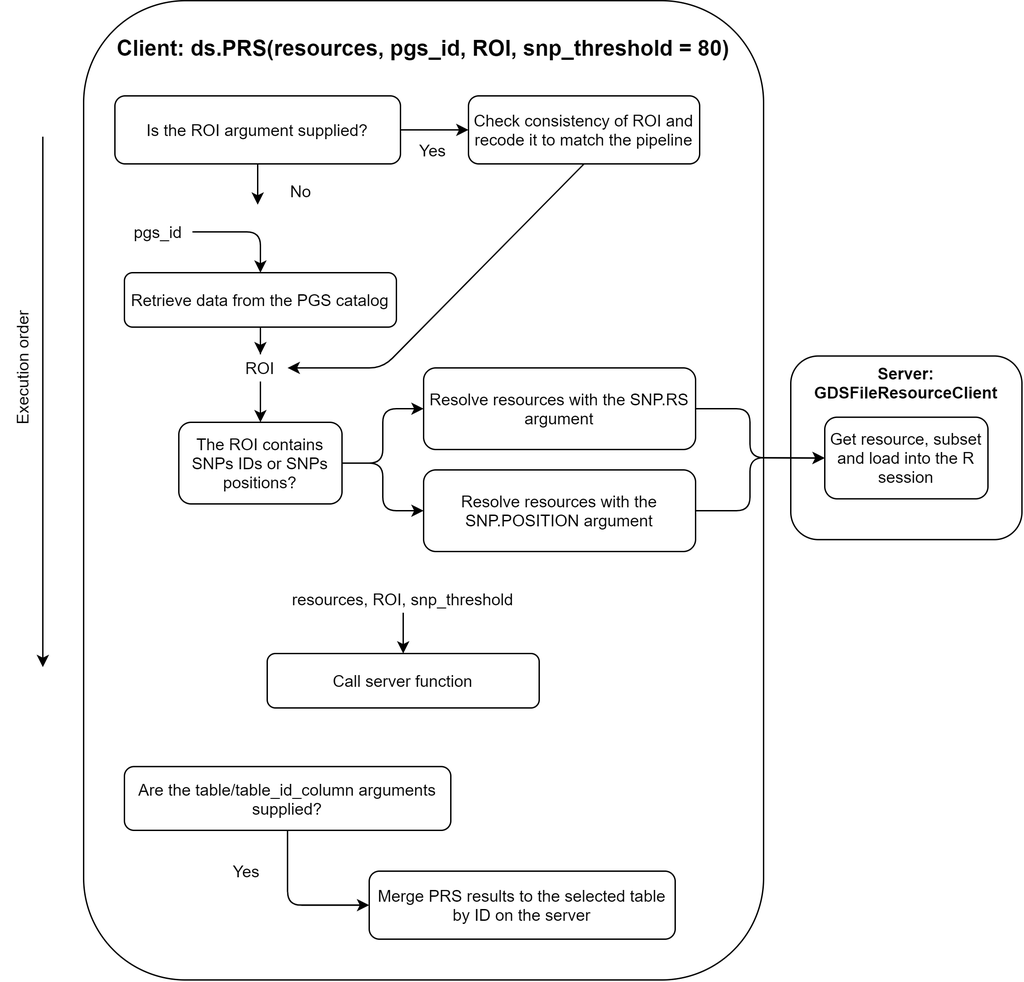

Figure 11: Flow chart of the client block

#### 3.4.2.2 Server resolver

The server resolver is in charge of resolving the resources. The interesting aspect is that only a region of interest is actually assigned to the R session, this is to avoid overloading the memory with unnecessary information. There are two different methodologies to perform this subsetting, one is using chromosome names and position and the other is using the SNP id’s. Due to the technical specification of VCF files, is much easier to perform the subsetting using chromosome names and positions because there is an indexing file for the VCF files to perform fast queries of regions by position. On the other hand, to filter a VCF file using SNP id’s, the whole file has to be scanned, yielding a much slower process.

This block is illustrated on the following figure.

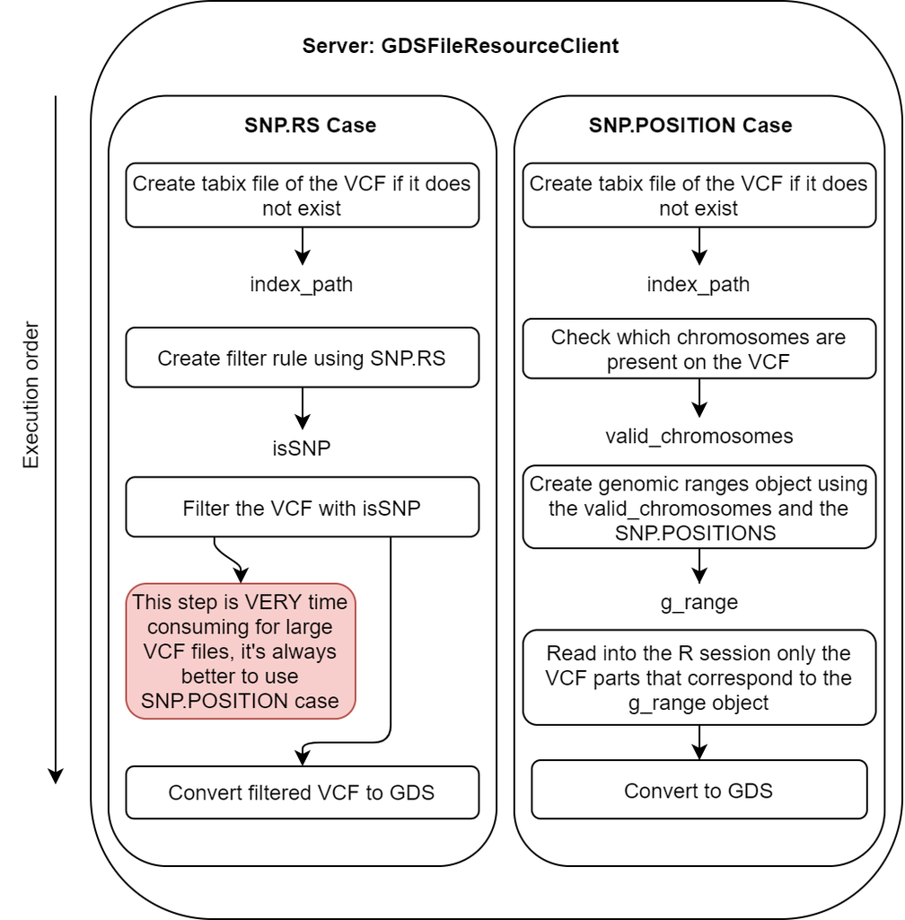

Figure 12: Flow chart of the server resolver block

#### 3.4.2.3 Server analysis

Many processes are performed inside the analysis block. For that reason, more than a flow chart, a step by step guide has been illustrated with the objects that are created (or modified) on each step. The most important step on this block is making sure that the alternate (risk) alleles match between the VCF resources and the alternate alleles stated by the `prs_table` or PGS Catalog.

The block is illustrated on the following figure.

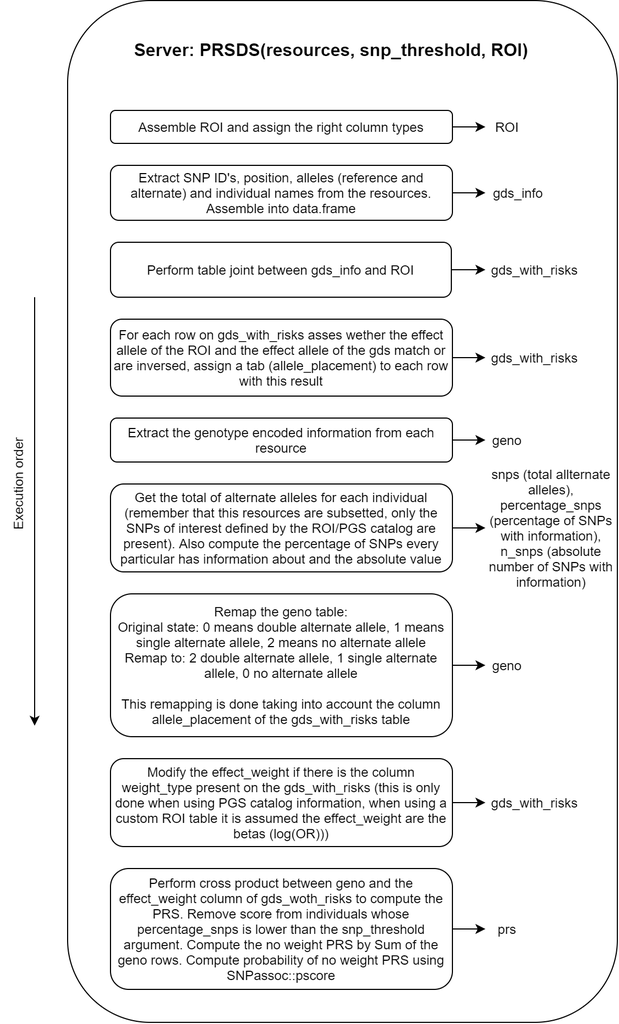

Figure 13: Flow chart of the server analysis block

# References

Escott-Price, Valentina, Amanda J Myers, Matt Huentelman, and John Hardy. 2017. “Polygenic Risk Score Analysis of Pathologically Confirmed Alzheimer Disease.” *Annals of Neurology* 82 (2): 311–14.

Forgetta, Vincenzo, Julyan Keller-Baruch, Marie Forest, Audrey Durand, Sahir Bhatnagar, John P Kemp, Maria Nethander, et al. 2020. “Development of a Polygenic Risk Score to Improve Screening for Fracture Risk: A Genetic Risk Prediction Study.” *PLoS Medicine* 17 (7): e1003152.

Kramer, Iris, Maartje J Hooning, Nasim Mavaddat, Michael Hauptmann, Renske Keeman, Ewout W Steyerberg, Daniele Giardiello, et al. 2020. “Breast Cancer Polygenic Risk Score and Contralateral Breast Cancer Risk.” *The American Journal of Human Genetics* 107 (5): 837–48.

Pirinen, Matti. 2020. “GWAS 9: Meta-Analysis and Summary Statistics.” https://www.mv.helsinki.fi/home/mjxpirin/GWAS_course/material/GWAS9.html.

Torkamani, Ali, Nathan E Wineinger, and Eric J Topol. 2018. “The Personal and Clinical Utility of Polygenic Risk Scores.” *Nature Reviews Genetics* 19 (9): 581–90.